# Sesión 6

Profesor:[Dr. José Manuel MAGALLANES REYES, Ph.D](http://www.pucp.edu.pe/profesor/jose-manuel-magallanes/%22%20target=%22_blank)

- Profesor Principal del Departamento de Ciencias Sociales, Sección de Ciencia Política y Gobierno.
- [Oficina 223](https://goo.gl/maps/xuGeG6o9di1i1y5m6) - Edificio CISEPA / ECONOMIA / CCSS
- Telefono: (51) 1 - 6262000 anexo 4302
- Correo Electrónico: jmagallanes@pucp.edu.pe

## Análisis de Variables Latentes (I)

[figure not shown]

Muchas veces queremos saber si algun conjunto de variables representa algun *concepto*, al cual se le denomina técnicamente *variable latente*. Las técnicas son variadas, pero en esta unidad veremos análisis factorial exploratorio, y en la próxima el confirmatorio para tratar de *reducir* varias variables en otra u otras más simples.

En esta unidad trabajaremos con la data de:

- [Índice de Desarrollo Humano (IDH)](https://hdr.undp.org/data-center/documentation-and-downloads)
- [Índice de Democracia del Economist (IDE)](https://en.wikipedia.org/wiki/The_Economist_Democracy_Index)

Este ejemplo usa dos índices calculados cada uno a partir de un conjunto de indicadores. Nuestro interés no está en los índices, sino en utilizar los indicadores para producir los indices usando las técnicas que veremos.

# 1 Carga de datos

Los datos los hemos preparado [previamente](https://rpubs.com/jmagallanes/Sesion6_Data):

```r
rm(list = ls()) # limpiar memoria
# carga
dataPreparada="https://github.com/Estadistica-AnalisisPolitico/Sesion6/raw/main/idhdemo.csv"
idhdemo=read.csv(dataPreparada)
```

# 2 Analisis Factorial Exploratorio (EFA)

El análisis factorial exploratorio (Watkins 2018), como su nombre indica, explora la data y nos entrega posibles factores que resumen cada uno un conjunto de variables. Seleccionemos la data que necesitamos:

```r
names(idhdemo)
```

```
##  [1] "country"          "hdiRanking"       "hdi"              "hdiLife"
##  [5] "hdiSchoolExpec"   "hdiMeanEduc"      "hdiGni"           "ideRanking"
##  [9] "ideRegime"        "ide"              "ideElectoral"     "ideFunctioning"
## [13] "ideParticipation" "ideCulture"       "ideLiberties"
```

Seleccionemos:

```r
dontselect=c("country","hdiRanking","hdi",
             "ideRanking","ideRegime","ide")
select=setdiff(names(idhdemo),dontselect)
theData=idhdemo[,select]

# usaremos:
library(magrittr)
head(theData,10)%>%
    rmarkdown::paged_table()
```

|  | hdiLife | hdiSchoolExpec | hdiMeanEduc | hdiGni | ideElectoral | ideFunctioning | ideParticipation | ideCulture | ideLiberties |
| --- | --- | --- | --- | --- | --- | --- | --- | --- | --- |
| 1 | 62.879 | 10.70538 | 2.514790 | 1335.206 | 0.00 | 0.07 | 0.00 | 1.25 | 0.00 |
| 2 | 76.833 | 14.48747 | 10.121144 | 15293.327 | 7.00 | 6.07 | 5.00 | 6.25 | 7.06 |
| 3 | 77.129 | 15.48788 | 6.987444 | 10978.406 | 3.08 | 2.50 | 3.89 | 5.00 | 3.82 |
| 4 | 61.929 | 12.16760 | 5.844292 | 5327.788 | 4.50 | 3.21 | 5.56 | 5.00 | 2.65 |
| 5 | 76.064 | 18.97951 | 11.144080 | 22047.971 | 9.17 | 5.00 | 7.22 | 3.75 | 7.94 |
| 6 | 73.372 | 14.40561 | 11.330300 | 15388.300 | 7.92 | 4.64 | 6.11 | 3.13 | 5.29 |
| 7 | 83.579 | 21.08002 | 12.726820 | 49257.135 | 10.00 | 8.57 | 7.22 | 7.50 | 10.00 |
| 8 | 82.412 | 16.36746 | 12.305714 | 56529.663 | 9.58 | 7.50 | 8.89 | 6.88 | 8.53 |
| 9 | 73.488 | 12.71063 | 10.556130 | 15018.054 | 0.50 | 2.50 | 3.33 | 5.00 | 2.65 |
| 10 | 79.246 | 16.29968 | 11.046590 | 48731.446 | 0.42 | 2.71 | 3.33 | 4.38 | 1.76 |

Calculemos las correlaciones entre todas las variables:

```r
library(polycor)
corMatrix=polycor::hetcor(theData)$correlations
```

El objeto *corMatrix* guarda las correlaciones entre todas las variables:

```r
round(corMatrix,2)
```

```
##                  hdiLife hdiSchoolExpec hdiMeanEduc hdiGni ideElectoral
## hdiLife             1.00           0.79        0.75   0.78         0.51
## hdiSchoolExpec      0.79           1.00        0.80   0.73         0.54
## hdiMeanEduc         0.75           0.80        1.00   0.71         0.50
## hdiGni              0.78           0.73        0.71   1.00         0.43
## ideElectoral        0.51           0.54        0.50   0.43         1.00
## ideFunctioning      0.65           0.66        0.60   0.62         0.85
## ideParticipation    0.51           0.57        0.53   0.45         0.80
## ideCulture          0.44           0.46        0.37   0.57         0.49
## ideLiberties        0.54           0.60        0.55   0.53         0.91
##                  ideFunctioning ideParticipation ideCulture ideLiberties
## hdiLife                    0.65             0.51       0.44         0.54
## hdiSchoolExpec             0.66             0.57       0.46         0.60
## hdiMeanEduc                0.60             0.53       0.37         0.55
## hdiGni                     0.62             0.45       0.57         0.53
## ideElectoral               0.85             0.80       0.49         0.91
## ideFunctioning             1.00             0.75       0.65         0.87
## ideParticipation           0.75             1.00       0.51         0.80
## ideCulture                 0.65             0.51       1.00         0.59
## ideLiberties               0.87             0.80       0.59         1.00
```

La Figura 2.1 grafica las correlaciones :

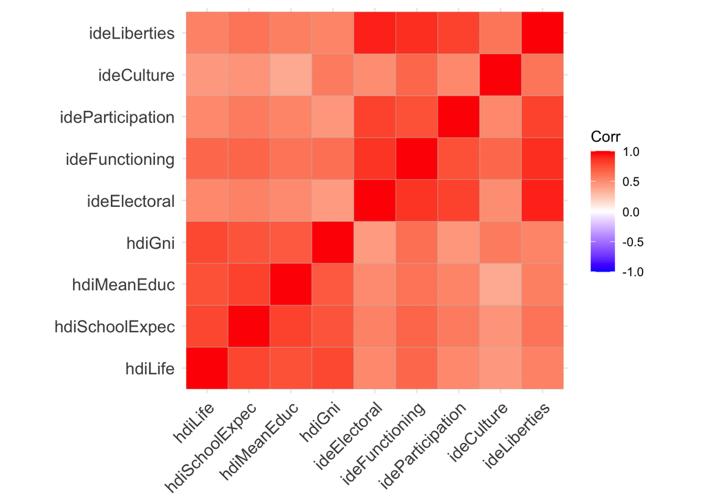

Figure 2.1: Matriz de Correlaciones

```r
library(ggcorrplot)

ggcorrplot(corMatrix)
```

Si puedes ver bloques de colores en la Figura 2.1 significa que esas variables representen algunos factores.

Veamos los pasos que el EFA requiere:

1. Verificar si los datos permiten factorizar:

```r
library(psych)
psych::KMO(corMatrix)
```

```
## Kaiser-Meyer-Olkin factor adequacy
## Call: psych::KMO(r = corMatrix)
## Overall MSA =  0.9
## MSA for each item =
##          hdiLife   hdiSchoolExpec      hdiMeanEduc           hdiGni
##             0.90             0.92             0.91             0.88
##     ideElectoral   ideFunctioning ideParticipation       ideCulture
##             0.84             0.93             0.96             0.87
##     ideLiberties
##             0.88
```

2. Verificar si la matriz de correlaciones es adecuada

Aquí hay dos pruebas:

- Hnula: La matriz de correlación es una [matriz identidad](https://en.wikipedia.org/wiki/Identity_matrix)

```r
cortest.bartlett(corMatrix,n=nrow(theData))$p.value>0.05
```

```
## [1] FALSE
```

- Hnula: La matriz de correlación es una [matriz singular](http://mathworld.wolfram.com/SingularMatrix.html).

```r
library(matrixcalc)

is.singular.matrix(corMatrix)
```

```
## [1] FALSE
```

3. Determinar en cuantos factores o variables latentes podríamos redimensionar la data: En este caso, la función *fa.parallel* nos dará la sugerencia:

```r
fa.parallel(theData, fa = 'fa',correct = T,plot = F)
```

```
## Parallel analysis suggests that the number of factors =  2  and the number of components =  NA
```

Se sugieren 2, lo esperado en teoría, sigamos.

4. Redimensionar a número menor de factores
- Resultado inicial:

```r
library(GPArotation)
resfa <- fa(theData,
            nfactors = 2,
            cor = 'mixed',
            rotate = "varimax", #oblimin?
            fm="minres")
print(resfa$loadings)
```

```
##
## Loadings:
##                  MR1   MR2
## hdiLife          0.307 0.836
## hdiSchoolExpec   0.368 0.811
## hdiMeanEduc      0.316 0.782
## hdiGni           0.283 0.813
## ideElectoral     0.906 0.249
## ideFunctioning   0.801 0.470
## ideParticipation 0.768 0.331
## ideCulture       0.498 0.382
## ideLiberties     0.901 0.334
##
##                  MR1   MR2
## SS loadings    3.522 3.280
## Proportion Var 0.391 0.364
## Cumulative Var 0.391 0.756
```

- Resultado mejorado (solo apropiado si hay más de un factor):

```r
print(resfa$loadings,cutoff = 0.5)
```

```
##
## Loadings:
##                  MR1   MR2
## hdiLife                0.836
## hdiSchoolExpec         0.811
## hdiMeanEduc            0.782
## hdiGni                 0.813
## ideElectoral     0.906
## ideFunctioning   0.801
## ideParticipation 0.768
## ideCulture
## ideLiberties     0.901
##
##                  MR1   MR2
## SS loadings    3.522 3.280
## Proportion Var 0.391 0.364
## Cumulative Var 0.391 0.756
```

Cuando logramos que cada variable se vaya a un factor, tenemos una *estructura simple*.

- Resultado visual: El resultado lo podemos ver de manera gráfica en la Figura 2.2.

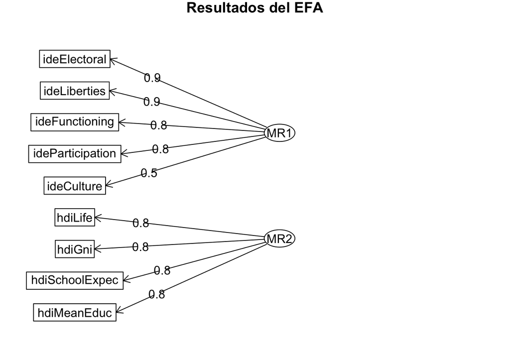

Figure 2.2: Variables organizadas en Factores

```r
fa.diagram(resfa,main = "Resultados del EFA")
```

5. Evaluando Resultado obtenido:
- ¿Qué variables aportaron más a los factores?

```r
sort(resfa$communality)
```

```
##       ideCulture ideParticipation      hdiMeanEduc           hdiGni
##        0.3941682        0.6993302        0.7119301        0.7405067
##          hdiLife   hdiSchoolExpec   ideFunctioning     ideElectoral
##        0.7933223        0.7936103        0.8629055        0.8835971
##     ideLiberties
##        0.9226321
```

- ¿Qué variables contribuyen a la construcción de más de un factor?

```r
sort(resfa$complexity)
```

```
##     ideElectoral           hdiGni          hdiLife     ideLiberties
##         1.150198         1.238563         1.265339         1.270410
##      hdiMeanEduc ideParticipation   hdiSchoolExpec   ideFunctioning
##         1.317113         1.358907         1.395523         1.614353
##       ideCulture
##         1.874466
```

- ¿Tucker Lewis > 0.9?

```r
resfa$TLI
```

```
## [1] 0.9263416
```

- ¿RMS cerca a cero?

```r
resfa$rms
```

```
## [1] 0.0346878
```

¿RMSEA cerca a cero?

```r
resfa$RMSEA
```

```
##      RMSEA      lower      upper confidence
##  0.1319641  0.1014027  0.1651144  0.9000000
```

- ¿BIC?

```r
resfa$BIC
```

```
## [1] -23.30257
```

# 3 Obtención de índices

Podemos calcular dos *indices* que resuman los dos factores encontrados.

```r
as.data.frame(resfa$scores)%>%head()
```

```
##          MR1         MR2
## 1 -1.6803401 -0.83207114
## 2  0.4219025  0.17017645
## 3 -0.8499736  0.38447261
## 4 -0.3312612 -0.83527332
## 5  0.6137348  0.55689007
## 6  0.1404683  0.08167183
```

Les daremos por nombre ‘ide_efa’ y ‘idh_efa’ a esas dos columnas. Dado que tenemos el indice de democracia en la data original, comparémoslo con el recién calculado, via el *scatterplot* de la Figura 3.1.

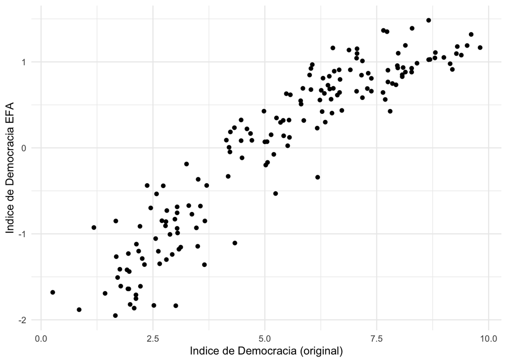

Figure 3.1: Comparando Indice de Democracia con el Score obtenido en EFA

```r
idhdemo$ide_efa=resfa$scores[,1]
idhdemo$idh_efa=resfa$scores[,2]

ggplot(data=idhdemo,aes(x=ide,y=ide_efa)) + geom_point() + theme_minimal() + labs(x="Indice de Democracia (original)", y="Indice de Democracia EFA")
```

Nota que los rangos de los valores en la Figura 3.1 no son los mismos. Podemos cambiar tales rangos:

```r
# normalizando
library(BBmisc)
efa_scores_norm=normalize(resfa$scores,
                       method = "range",
                       margin=2, # by column
                       range = c(0, 10))

# nuevas variables
idhdemo$ide_efa_norm=efa_scores_norm[,1]
idhdemo$idh_efa_norm=efa_scores_norm[,2]
```

La Figura 3.2 muestra las nuevas variables para IDE.

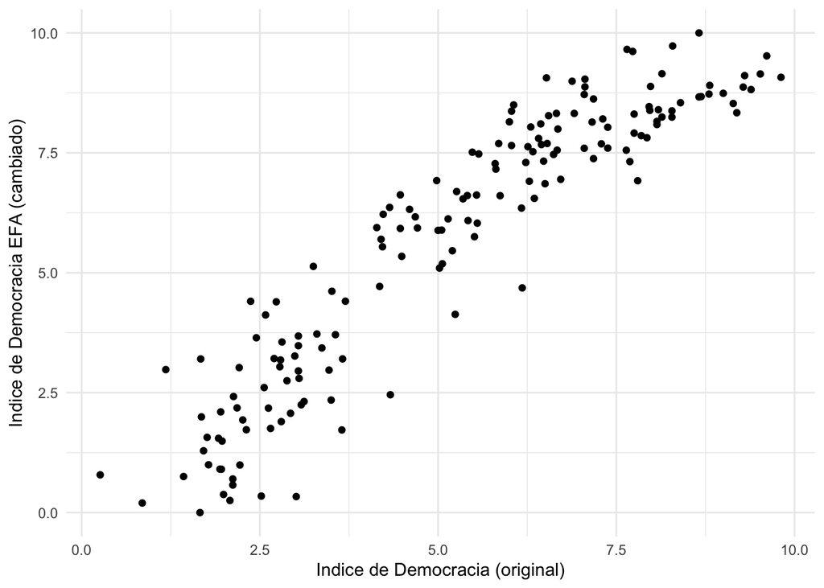

Figure 3.2: Comparación Indice de Democracia con Score EFA con rangos coincidentes

```r
# graficando

ggplot(data=idhdemo,aes(x=ide,y=ide_efa_norm)) + geom_point() + theme_minimal() + labs(x="Indice de Democracia (original)", y="Indice de Democracia EFA (cambiado)")
```

La Figura 3.3 muestra las nuevas variables para IDH.

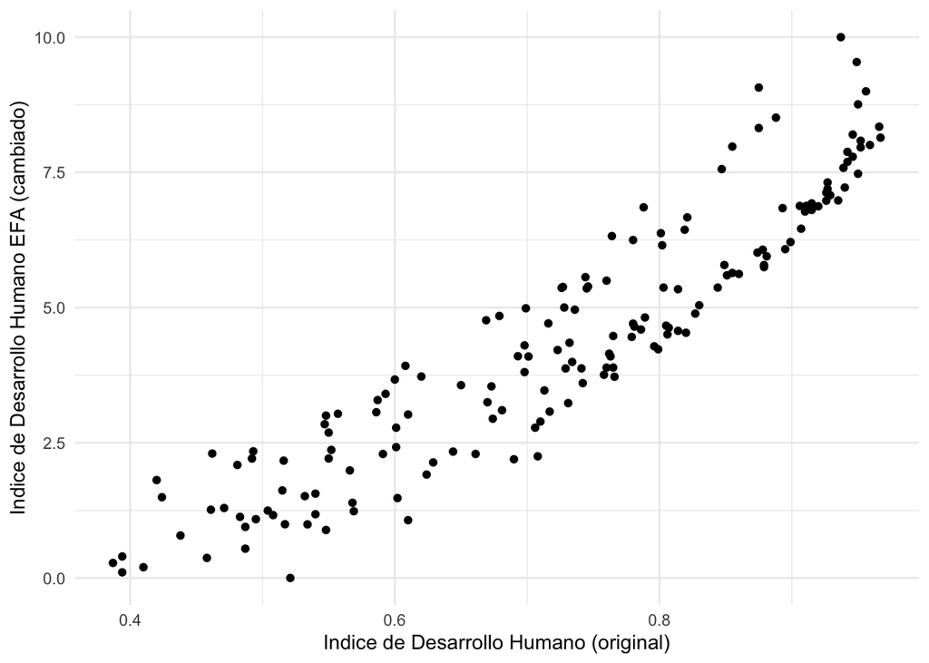

Figure 3.3: Comparación Indice de Desarrollo Humano con Score EFA con rangos coincidentes

```r
ggplot(data=idhdemo,aes(x=hdi,y=idh_efa_norm)) + geom_point() + theme_minimal() + labs(x="Indice de Desarrollo Humano (original)", y="Indice de Desarrollo Humano EFA (cambiado)")
```

Queda a esta altura preguntarse:

- ¿Qué ventaja hay entre calcular un índice como un resultado aritmético simple a partir de los indicadores versus usar análisis factorial con el mismo propósito?
- Finalmente, nota este resultado:

```r
cor(idhdemo$ide_efa_norm,idhdemo$idh_efa_norm)
```

```
## [1] 0.0632508
```

¿Qué crees que esto significa? ¿Qué relación tiene el Análisis factorial con la regresión? ¿Puede servir de algo en particular?

# Referencias

Watkins, Marley W. 2018. “Exploratory Factor Analysis: A Guide to Best Practice.” *Journal of Black Psychology* 44 (3): 219–46. https://doi.org/10.1177/0095798418771807.